# 📌 Extract: O E do ETL

### 💡 Filtrar linhas

Em planilhas, a alteração é com mouse, basta clicar (low-code, lembra da nossa aula de ferramentas?) Aqui é com o teclado high-code)!

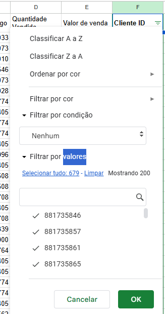

🔹 Mas e se a gente quiser filtrar algumas linhas? Podemos utilizar algo que "prende" apenas algumas linhas. Repare que ao invés de parêntese utilizamos colchetes. Isso porque loc é um indexador, não uma função. Isso significa que ele é usado para acessar elementos dentro do DataFrame, de forma semelhante a como acessamos elementos de listas ou dicionários em Python.

```python
df_receitas.loc[df_receitas["cliente_sexo"] == "Feminino"].head(3)
```

|  | atendimento_id | data_lancamento | receita_codigo | venda_quantidade | venda_valor | cliente_id | cliente_sexo | cliente_nascimento_data | cliente_origem | profissional_especialidade | pagamento_data | pagamento_forma |
| --- | --- | --- | --- | --- | --- | --- | --- | --- | --- | --- | --- | --- |
| 0 | 45443933211803 | 2024-05-31 | 881732900 | 1 | 250.0 | 933211803 | Feminino | 1998-01-26 | NaN | Cirurgia Plástica | 2024-06-12 | Pix |
| 1 | 45443913709155 | 2024-05-31 | 881732900 | 1 | 250.0 | 913709155 | Feminino | 1995-08-01 | NaN | Cirurgia Plástica | 2024-06-12 | Pix |
| 2 | 45441923179337 | 2024-05-29 | 879938579 | 1 | 1500.0 | 923179337 | Feminino | 1977-12-27 | Rede Social | Cirurgia Plástica | 2024-06-28 | Cartão de crédito à vista |

Ou de forma posicional, retorna as primeiras 5 linhas, Porque o index máximo é 4? Porque em Python a indexação começa no 0.

```python
df_receitas.iloc[0:5]
```

|  | atendimento_id | data_lancamento | receita_codigo | venda_quantidade | venda_valor | cliente_id | cliente_sexo | cliente_nascimento_data | cliente_origem | profissional_especialidade | pagamento_data | pagamento_forma |
| --- | --- | --- | --- | --- | --- | --- | --- | --- | --- | --- | --- | --- |
| 0 | 45443933211803 | 2024-05-31 | 881732900 | 1 | 250.0 | 933211803 | Feminino | 1998-01-26 | NaN | Cirurgia Plástica | 2024-06-12 | Pix |
| 1 | 45443913709155 | 2024-05-31 | 881732900 | 1 | 250.0 | 913709155 | Feminino | 1995-08-01 | NaN | Cirurgia Plástica | 2024-06-12 | Pix |
| 2 | 45441923179337 | 2024-05-29 | 879938579 | 1 | 1500.0 | 923179337 | Feminino | 1977-12-27 | Rede Social | Cirurgia Plástica | 2024-06-28 | Cartão de crédito à vista |
| 3 | 45441920676452 | 2024-05-29 | 881732900 | 1 | 250.0 | 920676452 | Feminino | 1994-11-11 | Rede Social | Cirurgia Plástica | 2024-06-05 | Pix |
| 4 | 45440886043406 | 2024-05-28 | 913583009 | 2 | 2160.0 | 886043406 | Feminino | 1991-06-01 | NaN | Cirurgia Plástica | 2024-06-27 | Cartão de crédito à vista |

🔹 Você também pode perguntar pelas linhas com a função .query(). Repare que aqui não estou reatribuindo o dataframe. E que também estou conjugando a função .head(), que já aprendemos.

```python
df_receitas.query("cliente_sexo == 'Feminino'").head(3)
```

|  | atendimento_id | data_lancamento | receita_codigo | venda_quantidade | venda_valor | cliente_id | cliente_sexo | cliente_nascimento_data | cliente_origem | profissional_especialidade | pagamento_data | pagamento_forma |
| --- | --- | --- | --- | --- | --- | --- | --- | --- | --- | --- | --- | --- |
| 0 | 45443933211803 | 2024-05-31 | 881732900 | 1 | 250.0 | 933211803 | Feminino | 1998-01-26 | NaN | Cirurgia Plástica | 2024-06-12 | Pix |
| 1 | 45443913709155 | 2024-05-31 | 881732900 | 1 | 250.0 | 913709155 | Feminino | 1995-08-01 | NaN | Cirurgia Plástica | 2024-06-12 | Pix |
| 2 | 45441923179337 | 2024-05-29 | 879938579 | 1 | 1500.0 | 923179337 | Feminino | 1977-12-27 | Rede Social | Cirurgia Plástica | 2024-06-28 | Cartão de crédito à vista |

🔹 E se tiver mais de uma condição? 🤔

Podemos utilizar operadores lógicos como & (Ambas as condições devem ser verdadeiras) e | (Pelo menos uma das condições deve ser verdadeira)

```python
df_receitas.columns
```

```
Index(['atendimento_id', 'data_lancamento', 'receita_codigo',
       'venda_quantidade', 'venda_valor', 'cliente_id', 'cliente_sexo',
       'cliente_nascimento_data', 'cliente_origem',
       'profissional_especialidade', 'pagamento_data', 'pagamento_forma'],
      dtype='object')
```

```python
df_receitas.loc[(df_receitas["cliente_sexo"] == "Feminino") & (df_receitas["pagamento_forma"] == "Pix")].head(3)
```

|  | atendimento_id | data_lancamento | receita_codigo | venda_quantidade | venda_valor | cliente_id | cliente_sexo | cliente_nascimento_data | cliente_origem | profissional_especialidade | pagamento_data | pagamento_forma |
| --- | --- | --- | --- | --- | --- | --- | --- | --- | --- | --- | --- | --- |
| 0 | 45443933211803 | 2024-05-31 | 881732900 | 1 | 250.0 | 933211803 | Feminino | 1998-01-26 | NaN | Cirurgia Plástica | 2024-06-12 | Pix |
| 1 | 45443913709155 | 2024-05-31 | 881732900 | 1 | 250.0 | 913709155 | Feminino | 1995-08-01 | NaN | Cirurgia Plástica | 2024-06-12 | Pix |
| 3 | 45441920676452 | 2024-05-29 | 881732900 | 1 | 250.0 | 920676452 | Feminino | 1994-11-11 | Rede Social | Cirurgia Plástica | 2024-06-05 | Pix |

```python
df_receitas.query("cliente_sexo == 'Feminino' & pagamento_forma == 'Pix'").head(3)
```

|  | atendimento_id | data_lancamento | receita_codigo | venda_quantidade | venda_valor | cliente_id | cliente_sexo | cliente_nascimento_data | cliente_origem | profissional_especialidade | pagamento_data | pagamento_forma |
| --- | --- | --- | --- | --- | --- | --- | --- | --- | --- | --- | --- | --- |
| 0 | 45443933211803 | 2024-05-31 | 881732900 | 1 | 250.0 | 933211803 | Feminino | 1998-01-26 | NaN | Cirurgia Plástica | 2024-06-12 | Pix |
| 1 | 45443913709155 | 2024-05-31 | 881732900 | 1 | 250.0 | 913709155 | Feminino | 1995-08-01 | NaN | Cirurgia Plástica | 2024-06-12 | Pix |
| 3 | 45441920676452 | 2024-05-29 | 881732900 | 1 | 250.0 | 920676452 | Feminino | 1994-11-11 | Rede Social | Cirurgia Plástica | 2024-06-05 | Pix |

Repare que dois códigos diferentes chegaram ao mesmo resultado. Interessante, não?

🔹 Mas e se quisermos filtrar linhas que contêm valores de uma lista específica. Também temos função para isso: .isin(). Simples assim: "Está dentro de".

```python
# Filtrar clientes que pagaram via Pix ou Cartão de Débito

df_receitas[df_receitas["pagamento_forma"].isin(["Pix", "Cartão de débito"])]['pagamento_forma'].value_counts()
```

| pagamento_forma | count |
| --- | --- |
| Pix | 878 |
| Cartão de débito | 99 |

**dtype:** int64

🔹 Ou filtrar algo que contém

```python
df_receitas.columns
```

```
Index(['atendimento_id', 'data_lancamento', 'receita_codigo',
       'venda_quantidade', 'venda_valor', 'cliente_id', 'cliente_sexo',
       'cliente_nascimento_data', 'cliente_origem',
       'profissional_especialidade', 'pagamento_data', 'pagamento_forma'],
      dtype='object')
```

```python
# Filtrar especialidades que contém "Logia"

df_receitas[df_receitas['profissional_especialidade'].str.contains('logia', case=False)]
```

|  | atendimento_id | data_lancamento | receita_codigo | venda_quantidade | venda_valor | cliente_id | cliente_sexo | cliente_nascimento_data | cliente_origem | profissional_especialidade | pagamento_data | pagamento_forma |
| --- | --- | --- | --- | --- | --- | --- | --- | --- | --- | --- | --- | --- |
| 48 | 45433881736664 | 2024-05-21 | 881734405 | 1 | 1100.0 | 881736664 | Feminino | NaT | NaN | Dermatologia | 2024-06-20 | Cartão de crédito à vista |
| 50 | 45433917317600 | 2024-05-21 | 879938562 | 1 | 750.0 | 917317600 | Feminino | 1995-06-22 | Indicação | Dermatologia | 2024-05-21 | Cartão de débito |
| 52 | 45429918962528 | 2024-05-17 | 889546389 | 1 | 2100.0 | 918962528 | Feminino | 1979-09-27 | NaN | Nutrologia | 2024-06-16 | Cartão de crédito à vista |
| 55 | 45429928838912 | 2024-05-17 | 879940708 | 1 | 400.0 | 928838912 | Feminino | 1981-07-05 | Indicação | Dermatologia | 2024-06-13 | Dinheiro |
| 60 | 45427901343866 | 2024-05-15 | 879941121 | 1 | 410.0 | 901343866 | Feminino | 2001-01-16 | Rede Social | Ginecologia | 2024-05-15 | Pix |
| ... | ... | ... | ... | ... | ... | ... | ... | ... | ... | ... | ... | ... |
| 1221 | 44623881735846 | 2022-03-03 | 881734405 | 1 | 1100.0 | 881735846 | Feminino | 1959-05-26 | Convênio | Dermatologia | 2022-03-03 | Pix |
| 1222 | 44623881735846 | 2022-03-03 | 879940708 | 1 | 400.0 | 881735846 | Feminino | 1959-05-26 | Convênio | Dermatologia | 2022-03-03 | Pix |
| 1223 | 44623881735913 | 2022-03-03 | 879940708 | 1 | 400.0 | 881735913 | Feminino | 1994-01-13 | NaN | Dermatologia | 2022-03-03 | Pix |
| 1224 | 44617881736392 | 2022-02-25 | 889542508 | 1 | 600.0 | 881736392 | Feminino | 1988-02-15 | Indicação | Nutrologia | 2022-03-07 | Cartão de débito |
| 1225 | 44617881736257 | 2022-02-25 | 889542508 | 1 | 600.0 | 881736257 | Masculino | 1991-04-20 | NaN | Nutrologia | 2022-03-04 | Pix |

594 rows × 12 columns

🔹 Você também pode filtrar coisas nulas ou não nulas. Como? Simplesmente digitando: "E ai, ta nulo?" ou "E ai, não ta nulo?"

```python
# Filtrar clientes onde o "cliente_origem" está ausente (NaN)
df_receitas[df_receitas["cliente_origem"].isna()].head(3).T
```

|  | 0 | 1 | 4 |
| --- | --- | --- | --- |
| atendimento_id | 45443933211803 | 45443913709155 | 45440886043406 |
| data_lancamento | 2024-05-31 00:00:00 | 2024-05-31 00:00:00 | 2024-05-28 00:00:00 |
| receita_codigo | 881732900 | 881732900 | 913583009 |
| venda_quantidade | 1 | 1 | 2 |
| venda_valor | 250.0 | 250.0 | 2160.0 |
| cliente_id | 933211803 | 913709155 | 886043406 |
| cliente_sexo | Feminino | Feminino | Feminino |
| cliente_nascimento_data | 1998-01-26 00:00:00 | 1995-08-01 00:00:00 | 1991-06-01 00:00:00 |
| cliente_origem | NaN | NaN | NaN |
| profissional_especialidade | Cirurgia Plástica | Cirurgia Plástica | Cirurgia Plástica |
| pagamento_data | 2024-06-12 00:00:00 | 2024-06-12 00:00:00 | 2024-06-27 00:00:00 |
| pagamento_forma | Pix | Pix | Cartão de crédito à vista |

Repare que agora além da conjugação da função .head(), também conjuguei o .T, que faz com que a tabela fique transversa. Isso é útil para ver várias colunas

```python
# Filtrar apenas os registros onde "cliente_sexo" NÃO é nulo
df_receitas[df_receitas["cliente_sexo"].notna()].head(3).T
```

|  | 0 | 1 | 2 |
| --- | --- | --- | --- |
| atendimento_id | 45443933211803 | 45443913709155 | 45441923179337 |
| data_lancamento | 2024-05-31 00:00:00 | 2024-05-31 00:00:00 | 2024-05-29 00:00:00 |
| receita_codigo | 881732900 | 881732900 | 879938579 |
| venda_quantidade | 1 | 1 | 1 |
| venda_valor | 250.0 | 250.0 | 1500.0 |
| cliente_id | 933211803 | 913709155 | 923179337 |
| cliente_sexo | Feminino | Feminino | Feminino |
| cliente_nascimento_data | 1998-01-26 00:00:00 | 1995-08-01 00:00:00 | 1977-12-27 00:00:00 |
| cliente_origem | NaN | NaN | Rede Social |
| profissional_especialidade | Cirurgia Plástica | Cirurgia Plástica | Cirurgia Plástica |
| pagamento_data | 2024-06-12 00:00:00 | 2024-06-12 00:00:00 | 2024-06-28 00:00:00 |
| pagamento_forma | Pix | Pix | Cartão de crédito à vista |

🔹 Por fim, uma última necessidade de filtragem pode ser a filtragem por data.

```python
# Filtrar vendas realizadas entre 01/01/2023 e 30/06/2023

df_receitas[df_receitas["data_lancamento"].between("2023-01-01", "2023-06-30")].head(3).T
```

|  | 794 | 795 | 796 |
| --- | --- | --- | --- |
| atendimento_id | 45107881736392 | 45107881736929 | 45106881735973 |
| data_lancamento | 2023-06-30 00:00:00 | 2023-06-30 00:00:00 | 2023-06-29 00:00:00 |
| receita_codigo | 889542508 | 889542508 | 879940996 |
| venda_quantidade | 1 | 1 | 3 |
| venda_valor | 700.0 | 700.0 | 6750.0 |
| cliente_id | 881736392 | 881736929 | 881735973 |
| cliente_sexo | Feminino | Não informado | Feminino |
| cliente_nascimento_data | 1988-02-15 00:00:00 | 1984-07-19 00:00:00 | 1972-06-22 00:00:00 |
| cliente_origem | Indicação | NaN | Indicação |
| profissional_especialidade | Nutrologia | Nutrologia | Dermatologia |
| pagamento_data | 2023-07-10 00:00:00 | 2023-07-07 00:00:00 | 2023-06-29 00:00:00 |
| pagamento_forma | Pix | Pix | Pix |